# Movie Rating

10.06.2021

## Main purpose

- Reproduce old project
- Check consistency of findings on a new dataset
- Use version control to make the project reproducible

## Reproduce old project

- new software (R vs. Stata)
- lack of documentation about data preparation -> we tried to rely on report but information attached was too vague
- not able to reproduce the exact results

## Data preparation

- originaly performed in Excel
- this time we focused on obtaining the same data rather than on reasonable decisions

## Preparation based on report description…

…did not result in the same outcome

Old:

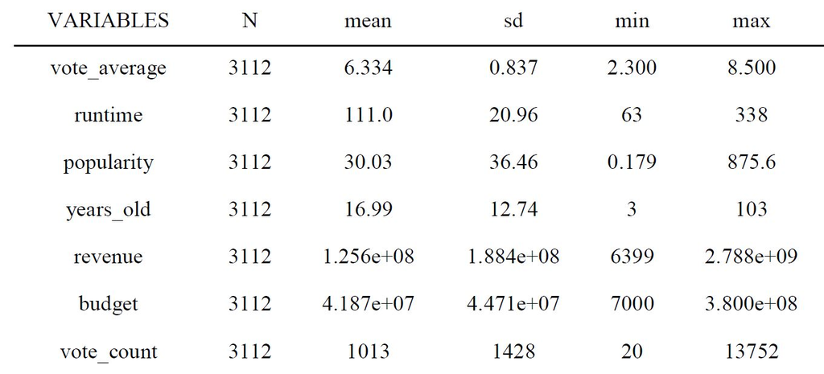

Reproduced:

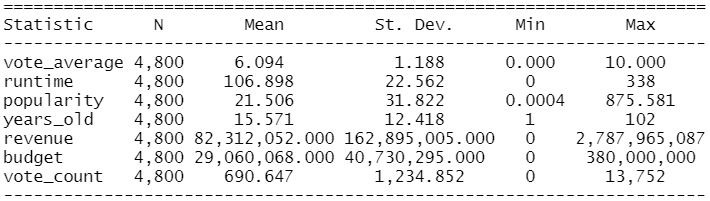

## Trimming values to the range from old project

Old:

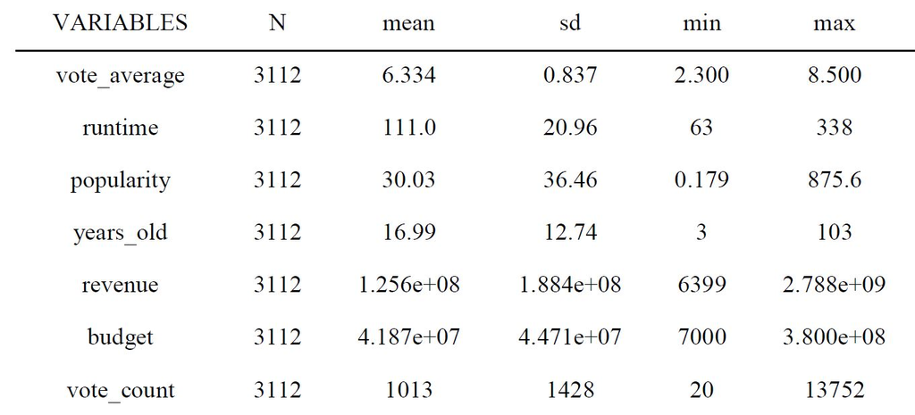

Reproduced:

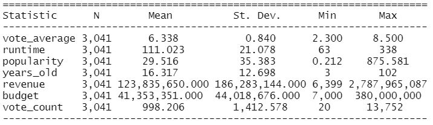

## Some differences

Old:

[figure not shown]

Reproduced:

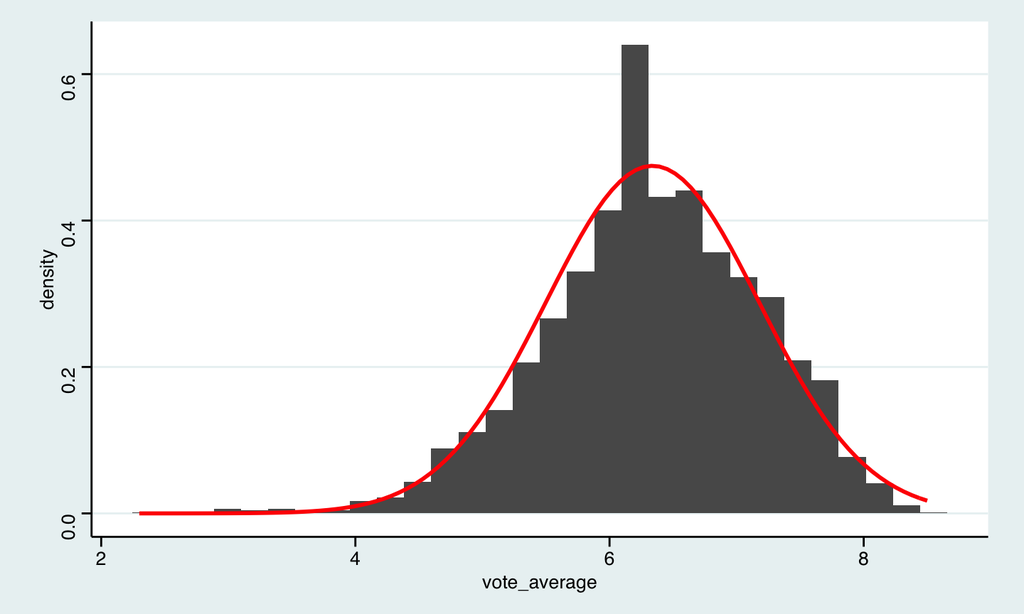

## Reproduced data variables correlation

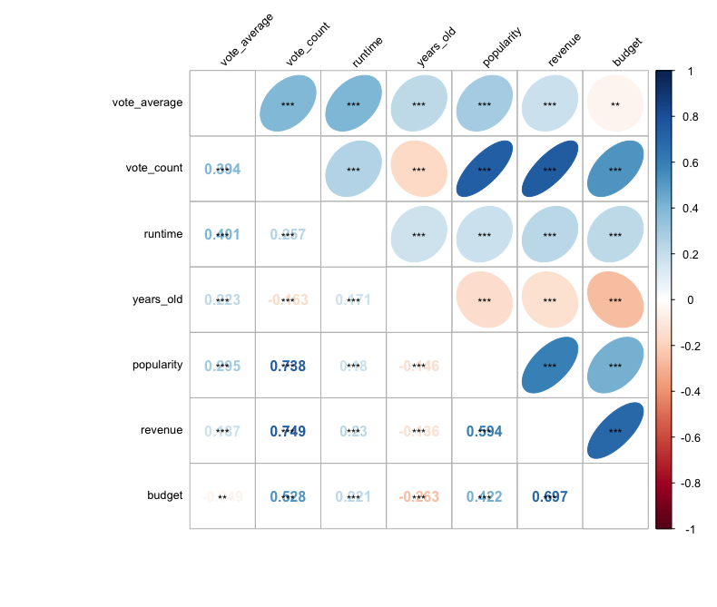

## Reproduced data variables histograms

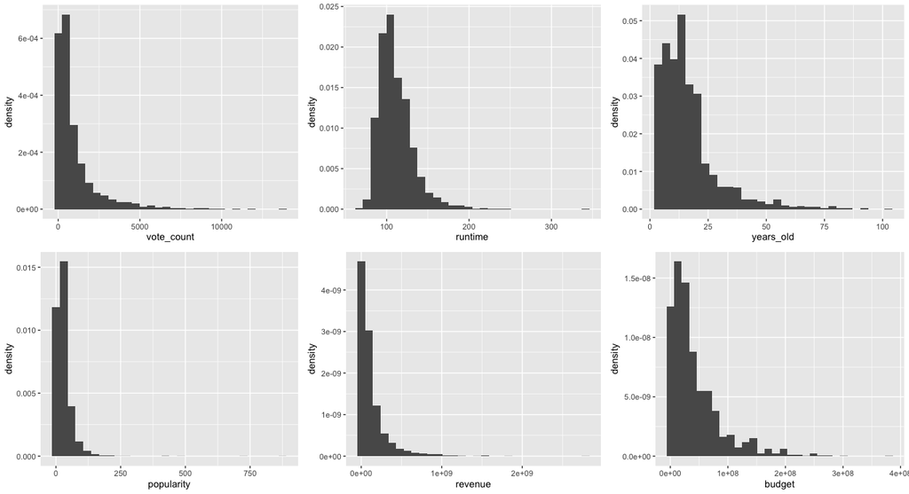

## Results

Old R² = 0.446

Reproduced R² = 0.44

## Old model summary

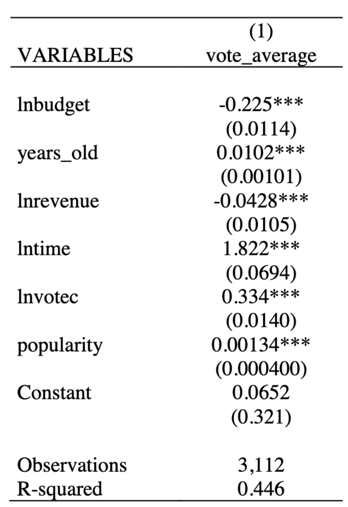

## Reproduced model summary

```
##     variables_names est_rep S.E_rep t_val_rep p_rep
## 1       (Intercept)   -0.51    0.39     -1.32  0.19
## 2         budget_ln   -0.25    0.01    -17.67  0.00
## 3         years_old    0.05    0.01      5.13  0.00
## 4 years_old_squared    0.00    0.00     -3.21  0.00
## 5        revenue_ln   -0.06    0.01     -4.18  0.00
## 6        runtime_ln    1.91    0.08     22.80  0.00
## 7     vote_count_ln    0.41    0.02     22.28  0.00
## 8        popularity    0.00    0.00      2.65  0.01
```

## Results - other conclusions

- quite similar at first glance
- passed RESET specification test originally
- failed RESET specification test at 5% of significance level
- error isn’t normally distributed (previously it probably was)

## Project based on a new dataset

- large dataset from the Kaggle platform containing 650 234 movies and TV shows
- applying exact same methods used in the reproduced project

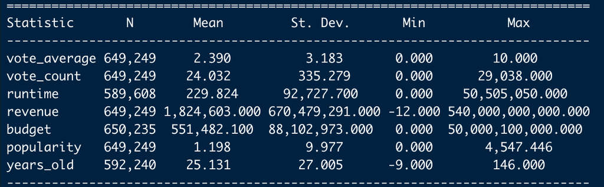

## Dependent variable density

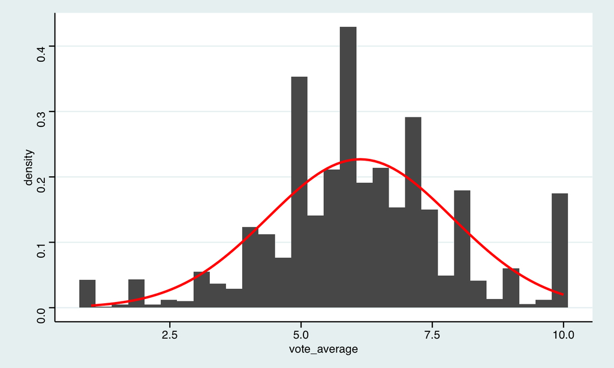

## New dataset variables correlations

- We can see the strong correlation between budget and revenue, but also between vote_count and revenue and budget

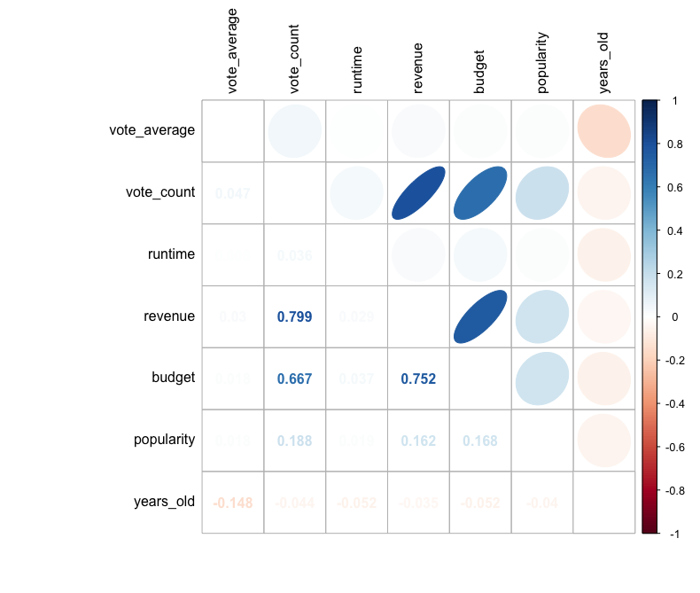

## Modelling

- Estimation of the model with all variables
- Revenue is not significant on 5% level of significance. We’ve seen that it is strongly skewed.
  - It may have zero or negative values so we’ll transform it with yeo-johnson transformation

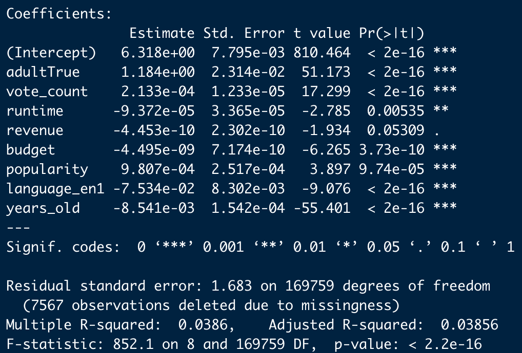

## Final model

- We added transformation of budget with natural logarithm
- There is hardly any difference in R² but revenue_yeo is significant now.

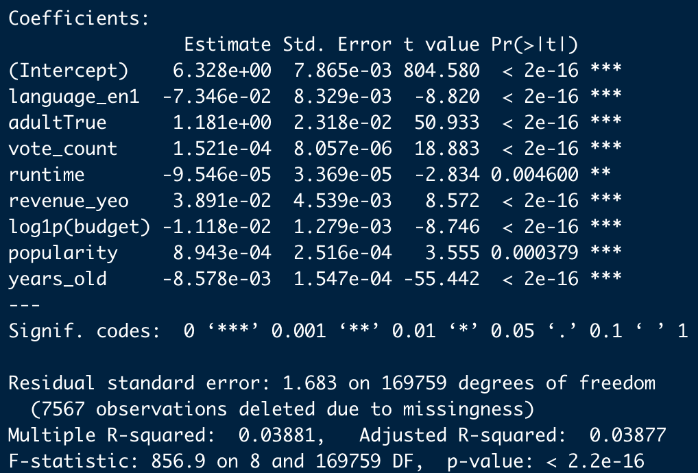

## Results

- Results on the test dataset:

MSE = 2.83, RMSE = 1.68, MAE = 1.26,

MedAE = 0.93, MSLE = 0.08, R² = 0.124

- R² a lot higher with prediction on the test dataset

## Additional thoughts

- The dependent variable is continuous, but it comes frome the likert scale, which is the ordinal measurement scale
  - It may cause problem, because we treat the target variable as a continuous, but people can not vote in such way
  - According to the market analyzes, people are more likely to choose the upper half of the scale, so the average vote is not a 5, bot more likely 6 or 7
- There is no one specific way to deal with such data across the literature